# Problem Set 4: Biased Methods and Regularization

Donggyun Kim

27008257

3/21/2018

# 1) Properties of PLS Regression

## a)

$||\mathbf{w}_h|| = \mathbf{w}_h^t\mathbf{w}_h =1.$

$\mathbf{p}_h = \frac{\mathbf{X}^t_{h-1}\mathbf{z}_h}{\mathbf{z}^{t}_h\mathbf{z}_h} = \frac{\mathbf{X}^t_{h-1}\mathbf{X}_{h-1}\mathbf{w}_h}{\mathbf{w}_h^t\mathbf{X}_{h-1}^t\mathbf{X}_{h-1}\mathbf{w}_h}.$

$\mathbf{w}_h^t\mathbf{p}_h = \frac{\mathbf{w}_h^t\mathbf{X}^t_{h-1}\mathbf{X}_{h-1}\mathbf{w}_h}{\mathbf{w}_h^t\mathbf{X}_{h-1}^t\mathbf{X}_{h-1}\mathbf{w}_h} = 1.$

## b)

$\mathbf{X}_h = \mathbf{X}_{h-1} - \mathbf{z}_h\mathbf{p}_h^t = \mathbf{X}_{h-1} - \mathbf{X}_{h-1}\mathbf{w}_h\mathbf{p}_h^t.$

$\mathbf{X}_h\mathbf{w}_h = \mathbf{X}_{h-1}\mathbf{w}_h - \mathbf{X}_{h-1}\mathbf{w}_h\mathbf{p}_h^t\mathbf{w}_h.$

$\mathbf{w}_h^t\mathbf{X}_h^t = (\mathbf{X}_h\mathbf{w}_h)^t = \mathbf{w}_h^t\mathbf{X}_{h-1}^t - \mathbf{w}_h^t\mathbf{p}_h\mathbf{w}_h^t \mathbf{X}_{h-1}^t = \mathbf{w}_h^t\mathbf{X}_{h-1}^t - \mathbf{w}_h^t \mathbf{X}_{h-1}^t = 0.$

# 2) Bias of Regression Coefficients in PCR

## a)

$\hat\beta_Z^{(k)} = V_k\hat{\beta}_{PCR}^{(k)}.$

$\mathbb{E}[V_k\hat{\beta}_{PCR}^{(k)}] = V_k(Z_k^tZ_k)^{-1}Z_k^t\mathbb{E}[y] = V_k(\Lambda_k)^{-1}(XV_k)^t(X\beta) = V_k(\Lambda_k)^{-1}V_k^tX^tX\beta.$

$\mathbb{E}[V_k\hat{\beta}_{PCR}^{(k)} - \beta] = \mathbb{E}[V_k\hat{\beta}_{PCR}^{(k)}] - \beta = V_k(\Lambda_k)^{-1}V_k^tX^tX\beta - \beta = (V_k(\Lambda_k)^{-1}V_k^tX^tX - I)\beta.$

## b)

$\hat\beta_Z^{(p)} = V_p\hat{\beta}_{PCR}^{(p)}.$

$\mathbb{E}[V_p\hat{\beta}_{PCR}^{(p)}] = V_p(Z_p^tZ_p)^{-1}Z_p^t\mathbb{E}[y] = V_p((XV_p)^tXV_p)^{-1}(XV_p)^t(X\beta) = V_p(V_p^tX^tXV_p)^{-1}V_p^tX^tX\beta = V_pV_p^t(X^tX)^{-1}V_pV_p^tX^tX\beta = \beta.$

$\mathbb{E}[V_p\hat{\beta}_{PCR}^{(p)} - \beta] = 0.$

# 3) Bias of Ridge Regression Coefficients

$X = UDV^t.$

$\hat\beta_r = (X^tX + kI)^{-1}X^ty = ((UDV^t)^tUDV^t + kI)^{-1}(UDV^t)^ty = (VD^2V^t+kI)^{-1}VDU^ty.$

$\mathbb{E}[\hat\beta_r] = (VD^2V^t+kI)^{-1}VDU^tX\beta = (VD^2V^t+kI)^{-1}VDU^tUDV^t\beta = (VD^2V^t+kI)^{-1}VD^2V^t\beta.$

$D^2 = \Lambda.$

$\mathbb{E}[\hat\beta_r - \beta] = \mathbb{E}[\hat\beta_r] - \beta = (V\Lambda V^t+kI)^{-1}V\Lambda V^t\beta - \beta = ((V\Lambda V^t+kI)^{-1}V\Lambda V^t - I)\beta.$

# 4) Models for Solubility Data

## 4.1) PCR

```r
library(AppliedPredictiveModeling)
library(caret)
library(pls)
library(elasticnet)
library(ggplot2)

data(solubility)

# 10-fold cross-validation
ctrl <- trainControl(method = "cv", number = 10)

set.seed(1991)
pcr_fit <- train(x = solTrainXtrans, y = solTrainY,
                 method = "pcr",
                 tuneLength = 40,
                 trControl = ctrl,
                 preProcess = c("center", "scale"))
pcr_fit
```

```
## Principal Component Analysis
##
## 951 samples
## 228 predictors
##
## Pre-processing: centered (228), scaled (228)
## Resampling: Cross-Validated (10 fold)
## Summary of sample sizes: 855, 857, 855, 857, 857, 855, ...
## Resampling results across tuning parameters:
##
##   ncomp  RMSE       Rsquared    MAE
##    1     2.0393844  0.01330618  1.5768251
##    2     1.9802436  0.08618857  1.5600094
##    3     1.7098785  0.30775962  1.3508311
##    4     1.6039381  0.38902366  1.2491550
```

[output cut: 39 more lines]

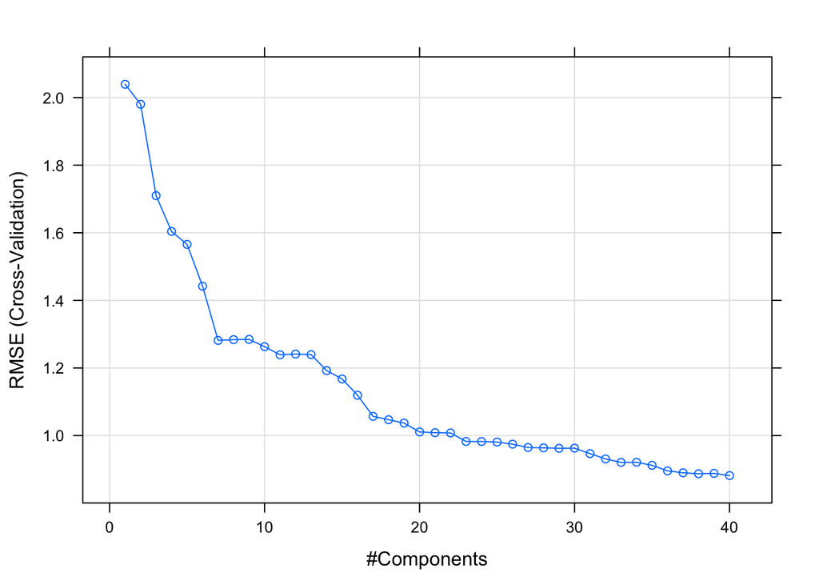

```r
# plot the RMSEs against the number of PCs
plot(pcr_fit)
```

```r
# the number of PCs that gives the minimum RMSE value
pcr_fit$bestTune
```

```
##    ncomp
## 40    40
```

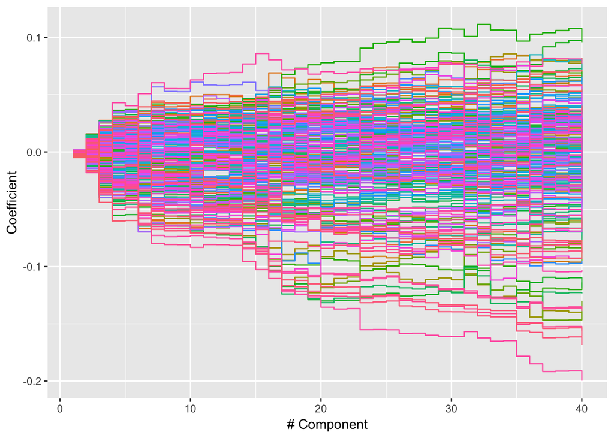

```r
# Make a plot of the regression coefficient paths
pcr_coef <- pcr_fit$finalModel$coefficients
n <- nrow(pcr_coef)
p <- as.numeric(pcr_fit$bestTune)
variable <- rep(rownames(pcr_coef), p)
PC <- rep(1:p, each = n)
pcr_coef <- as.matrix(pcr_coef)
dat <- data.frame(variable,
                  coefficient = pcr_coef,
                  PC,
                  stringsAsFactors = FALSE)

ggplot(dat, aes(x = PC, y = coefficient, col = variable)) +
  geom_step() +
  xlab("# Component") +
  ylab("Coefficient") +
  theme(legend.position = "none")
```

## 4.2) PLSR

```r
set.seed(1991)
pls_fit <- train(x = solTrainXtrans, y = solTrainY,
                 method = "pls",
                 tuneLength = 30,
                 trControl = ctrl,
                 preProcess = c("center", "scale"))

pls_fit
```

```
## Partial Least Squares
##
## 951 samples
## 228 predictors
##
## Pre-processing: centered (228), scaled (228)
## Resampling: Cross-Validated (10 fold)
## Summary of sample sizes: 855, 857, 855, 857, 857, 855, ...
## Resampling results across tuning parameters:
##
##   ncomp  RMSE       Rsquared   MAE
##    1     1.2834799  0.6039945  0.9916002
##    2     1.0565748  0.7313375  0.8338149
##    3     0.9421131  0.7896398  0.7295970
##    4     0.8672854  0.8202404  0.6763828
```

[output cut: 29 more lines]

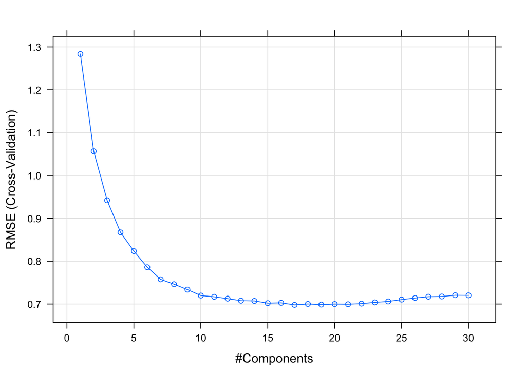

```r
# plot the RMSEs against the number of PLS components
plot(pls_fit)
```

```r
# the number of PLS components that gives the minimum RMSE value
pls_fit$bestTune
```

```
##    ncomp
## 17    17
```

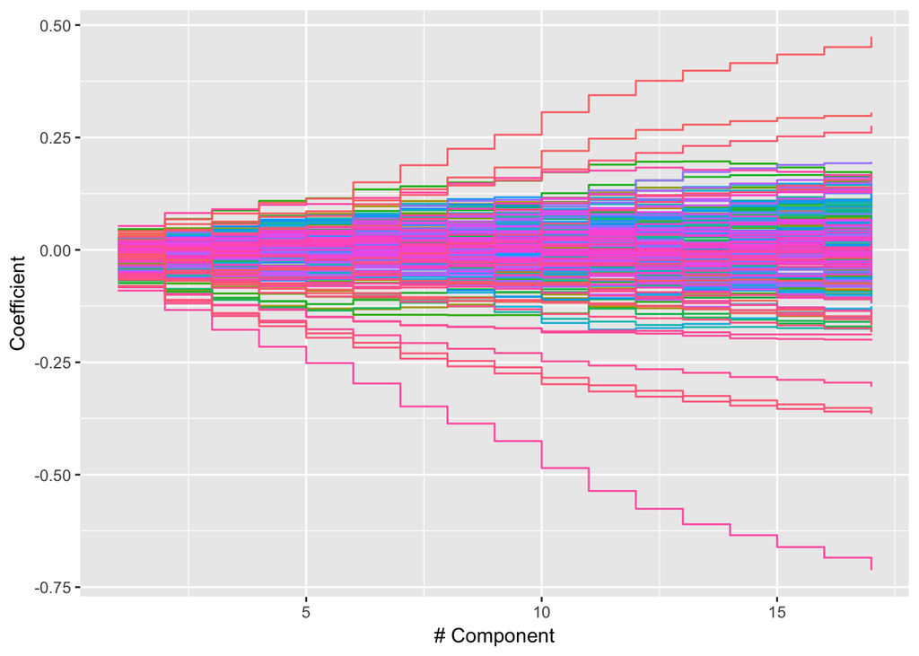

```r
# make a plot of the regression coefficient paths
pls_coef <- pls_fit$finalModel$coefficients
n <- nrow(pls_coef)
p <- as.numeric(pls_fit$bestTune)
variable <- rep(rownames(pls_coef), p)
comp <- rep(1:p, each = n)
pls_coef <- as.matrix(pls_coef)

dat <- data.frame(variable,
                  coefficient = pls_coef,
                  comp)

ggplot(dat, aes(x = comp, y = coefficient, col = variable)) +
  geom_step() +
  xlab("# Component") +
  ylab("Coefficient") +
  theme(legend.position = "none")
```

## 4.3) Ridge Regression

```r
ridgeGrid <- data.frame(.lambda = seq(0, .1, length = 15))
set.seed(1991)
ridge_fit <- train(x = solTrainXtrans, y = solTrainY,
                 method = "ridge",
                 tuneGrid = ridgeGrid,
                 trControl = ctrl,
                 preProcess = c("center", "scale"))

ridge_fit
```

```
## Ridge Regression
##
## 951 samples
## 228 predictors
##
## Pre-processing: centered (228), scaled (228)
## Resampling: Cross-Validated (10 fold)
## Summary of sample sizes: 855, 857, 855, 857, 857, 855, ...
## Resampling results across tuning parameters:
##
##   lambda       RMSE       Rsquared   MAE
##   0.000000000  0.7071944  0.8814257  0.5257221
##   0.007142857  0.6919235  0.8869550  0.5236807
##   0.014285714  0.6856703  0.8890874  0.5203141
##   0.021428571  0.6836460  0.8898722  0.5199234
##   0.028571429  0.6835001  0.8900898  0.5213092
##   0.035714286  0.6844180  0.8900088  0.5230327
##   0.042857143  0.6860243  0.8897518  0.5248594
##   0.050000000  0.6881167  0.8893846  0.5270827
##   0.057142857  0.6905749  0.8889460  0.5295143
##   0.064285714  0.6933224  0.8884605  0.5321482
##   0.071428571  0.6963083  0.8879441  0.5348864
##   0.078571429  0.6994975  0.8874080  0.5378075
##   0.085714286  0.7028648  0.8868596  0.5407873
##   0.092857143  0.7063920  0.8863046  0.5438502
##   0.100000000  0.7100654  0.8857467  0.5469702
##
## RMSE was used to select the optimal model using the smallest value.
## The final value used for the model was lambda = 0.02857143.
```

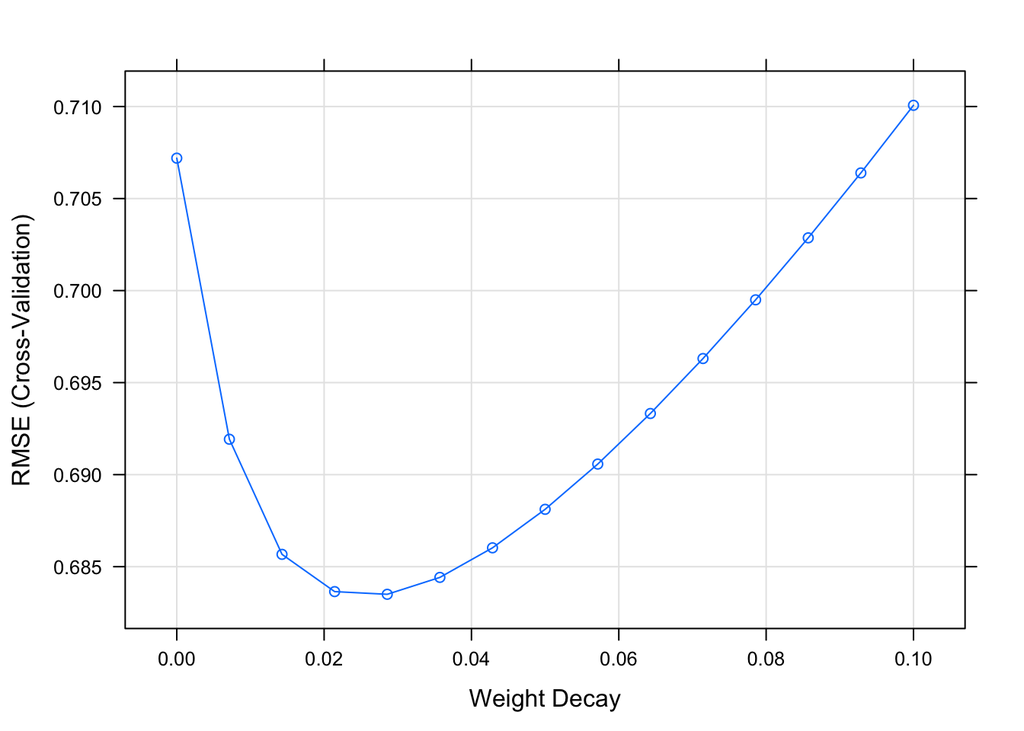

```r
# plot the RMSEs against the values of the tuning parameter lambda
plot(ridge_fit)
```

```r
# the value of lambda that gives the minimum RMSE value
ridge_fit$bestTune
```

```
##       lambda
## 5 0.02857143
```

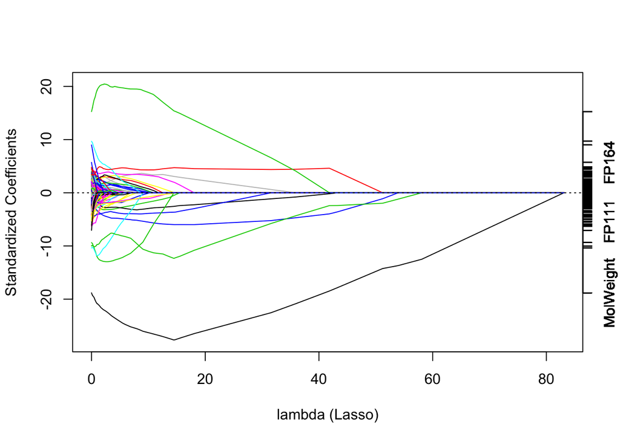

```r
# make a plot of the regression coefficient paths
plot(ridge_fit$finalModel, xvar = "penalty", use.color = TRUE)
```

## 4.4) Lasso

```r
enetGrid <- expand.grid(.lambda = c(0, 0.01, .1),
                        .fraction = seq(.05, 1, length = 20))
set.seed(1991)
lasso_fit <- train(x = solTrainXtrans, y = solTrainY,
                   method = "enet",
                   tuneGrid = enetGrid,
                   trControl = ctrl,
                   preProcess = c("center", "scale"))

lasso_fit
```

```
## Elasticnet
##
## 951 samples
## 228 predictors
##
## Pre-processing: centered (228), scaled (228)
## Resampling: Cross-Validated (10 fold)
## Summary of sample sizes: 855, 857, 855, 857, 857, 855, ...
## Resampling results across tuning parameters:
##
##   lambda  fraction  RMSE       Rsquared   MAE
##   0.00    0.05      0.8694393  0.8367154  0.6593669
##   0.00    0.10      0.6882519  0.8883257  0.5249954
##   0.00    0.15      0.6714866  0.8931908  0.5133845
##   0.00    0.20      0.6701005  0.8935851  0.5125415
##   0.00    0.25      0.6769459  0.8914827  0.5126865
##   0.00    0.30      0.6843558  0.8890745  0.5179973
##   0.00    0.35      0.6918879  0.8866338  0.5234601
##   0.00    0.40      0.6970105  0.8849352  0.5280080
##   0.00    0.45      0.6981910  0.8845023  0.5288807
##   0.00    0.50      0.6981295  0.8844524  0.5284216
##   0.00    0.55      0.6981444  0.8844082  0.5278100
##   0.00    0.60      0.6981516  0.8843850  0.5269660
##   0.00    0.65      0.6985908  0.8842072  0.5259632
##   0.00    0.70      0.6994292  0.8838955  0.5254815
##   0.00    0.75      0.7001222  0.8836637  0.5251417
##   0.00    0.80      0.7009164  0.8834005  0.5248366
##   0.00    0.85      0.7021745  0.8830045  0.5247800
##   0.00    0.90      0.7035777  0.8825485  0.5248372
##   0.00    0.95      0.7052453  0.8820344  0.5251640
##   0.00    1.00      0.7071944  0.8814257  0.5257221
##   0.01    0.05      1.5172575  0.6481926  1.1629621
##   0.01    0.10      1.1316121  0.7707836  0.8644227
##   0.01    0.15      0.9022421  0.8266589  0.6836986
##   0.01    0.20      0.7849595  0.8580220  0.5983956
##   0.01    0.25      0.7280635  0.8755480  0.5555230
##   0.01    0.30      0.6990802  0.8845478  0.5341814
##   0.01    0.35      0.6854148  0.8887916  0.5246724
##   0.01    0.40      0.6783782  0.8909363  0.5192493
##   0.01    0.45      0.6749279  0.8919645  0.5173129
```

[output cut: 19 more lines]

```
##   0.10    0.45      0.7352072  0.8716584  0.5647150
##   0.10    0.50      0.7254667  0.8759264  0.5577237
##   0.10    0.55      0.7189654  0.8789894  0.5534675
##   0.10    0.60      0.7145841  0.8810958  0.5507771
##   0.10    0.65      0.7112406  0.8827524  0.5481277
##   0.10    0.70      0.7106350  0.8834483  0.5473125
##   0.10    0.75      0.7105176  0.8838941  0.5467777
##   0.10    0.80      0.7103955  0.8843254  0.5466359
##   0.10    0.85      0.7103572  0.8847166  0.5469637
##   0.10    0.90      0.7103120  0.8850839  0.5471206
##   0.10    0.95      0.7102830  0.8854133  0.5471128
##   0.10    1.00      0.7100654  0.8857467  0.5469702
##
## RMSE was used to select the optimal model using the smallest value.
## The final values used for the model were fraction = 0.6 and lambda = 0.01.
```

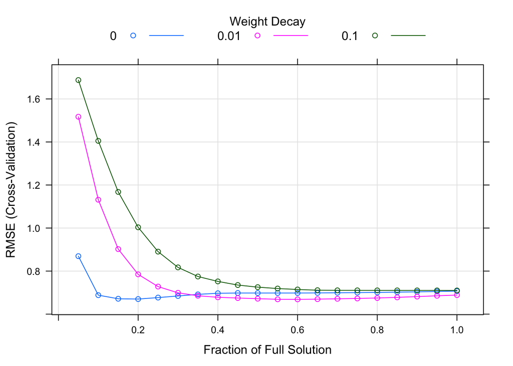

```r
# plot the RMSEs against the values of the tuning parameter lambda
plot(lasso_fit)
```

```r
# the value of lambda that gives the minimum RMSE value
lasso_fit$bestTune
```

```
##    fraction lambda
## 32      0.6   0.01
```

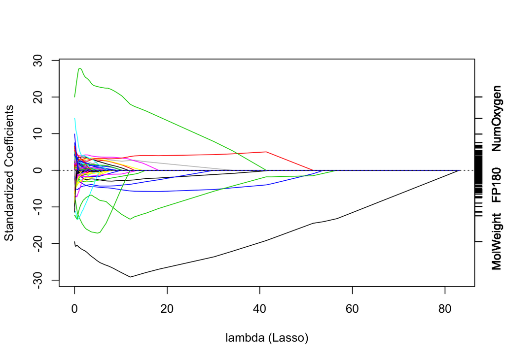

```r
# make a plot of the regression coefficient paths
plot(lasso_fit$finalModel, xvar = "penalty", use.color = TRUE)
```

## 4.5) Model Selection

```r
# compute test-MSEs for PCR
y_pcr <- predict(pcr_fit, solTestXtrans)
MSE_pcr <- mean((solTestY - y_pcr)^2)
MSE_pcr
```

```
## [1] 0.8070032
```

```r
# compute test-MSEs for PLSR
y_pls <- predict(pls_fit, solTestXtrans)
MSE_pls <- mean((solTestY - y_pls)^2)
MSE_pls
```

```
## [1] 0.5326949
```

```r
# compute test-MSEs for Ridge Regression
y_ridge <- predict(ridge_fit, solTestXtrans)
MSE_ridge <- mean((solTestY - y_ridge)^2)
MSE_ridge
```

```
## [1] 0.5182821
```

```r
# compute test-MSEs for PCR
y_lasso <- predict(lasso_fit, solTestXtrans)
MSE_lasso <- mean((solTestY - y_lasso)^2)
MSE_lasso
```

```
## [1] 0.5001638
```

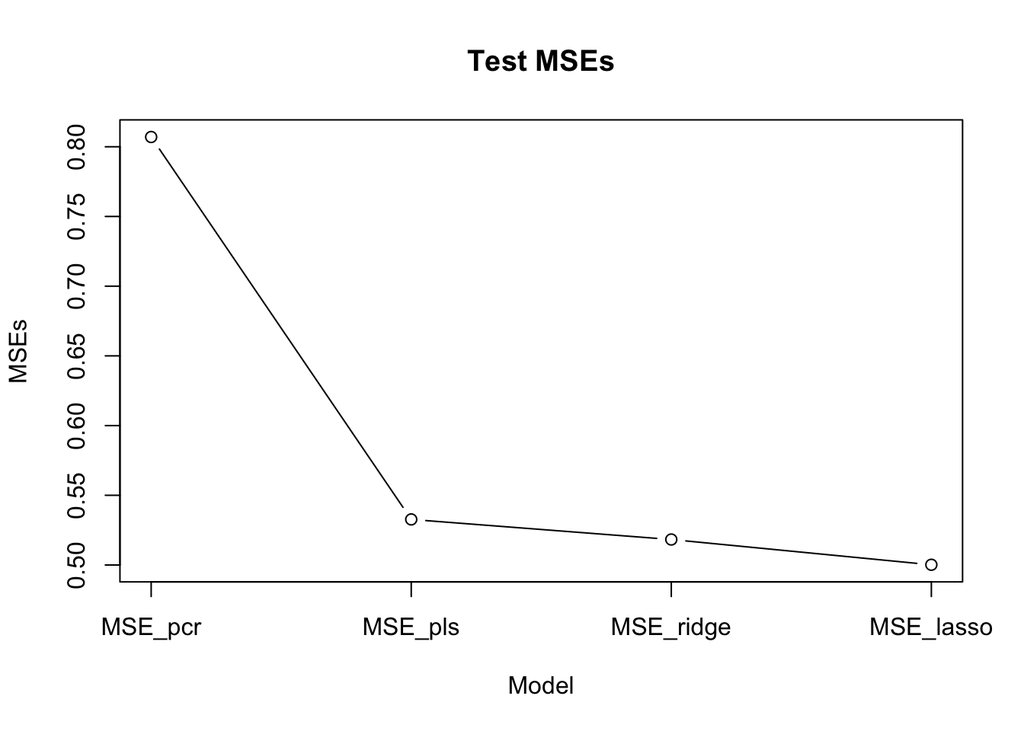

```r
# graph the test-MSEs
MSEs <- rbind(MSE_pcr, MSE_pls, MSE_ridge, MSE_lasso)
plot(MSEs, main = "Test MSEs", xlab = "Model", type = "b", xaxt = "n")
axis(1, at = 1:4, labels = rownames(MSEs))
```

```r
# the smallest test-MSE
MSEs[which.min(MSEs), 1]
```

```
## MSE_lasso
## 0.5001638
```